# Coffee Ratings EDA

Sultan Alkadhi

2022-06-22

In this exploratory analysis, we have used the dataset that was originally scraped from the Coffee Quality Institute (CQI) reviews page. CQI is a non-profit that offers a standardization system for grading high quality coffees to help bring them to the market. After their review process (termed coffee cupping), fresh coffee beans are assessed on ten different measures with a possible score of 0-10 for a final score of 0-100. In addition, the dataset includes information about country of origin and the region’s altitudes in meters. The two types of beans (species) that go through CQI’s verification system are Arabica and Robusta.

# Data

Check data cleanliness

```r
(na_count <-sapply(coffee_ratings, function(y) sum(length(which(is.na(y))))))
```

```
##      total_cup_points               species                 owner
##                     0                     0                     7
##     country_of_origin             farm_name            lot_number
##                     1                   359                  1063
##                  mill            ico_number               company
##                   315                   151                   209
##              altitude                region              producer
##                   226                    59                   231
##        number_of_bags            bag_weight    in_country_partner
##                     0                     0                     0
##          harvest_year          grading_date               owner_1
##                    47                     0                     7
##               variety     processing_method                 aroma
##                   226                   170                     0
##                flavor            aftertaste               acidity
##                     0                     0                     0
##                  body               balance            uniformity
##                     0                     0                     0
##             clean_cup             sweetness         cupper_points
##                     0                     0                     0
##              moisture  category_one_defects               quakers
##                     0                     0                     1
##                 color  category_two_defects            expiration
##                   218                     0                     0
##    certification_body certification_address certification_contact
##                     0                     0                     0
##   unit_of_measurement   altitude_low_meters  altitude_high_meters
##                     0                   230                   230
##  altitude_mean_meters
##                   230
```

Check data types

```r
glimpse(coffee_ratings)
```

```
## Rows: 1,339
## Columns: 43
## $ total_cup_points      <dbl> 90.58, 89.92, 89.75, 89.00, 88.83, 88.83, 88.75,…
## $ species               <chr> "Arabica", "Arabica", "Arabica", "Arabica", "Ara…
## $ owner                 <chr> "metad plc", "metad plc", "grounds for health ad…
## $ country_of_origin     <chr> "Ethiopia", "Ethiopia", "Guatemala", "Ethiopia",…
## $ farm_name             <chr> "metad plc", "metad plc", "san marcos barrancas …
## $ lot_number            <chr> NA, NA, NA, NA, NA, NA, NA, NA, NA, NA, NA, NA, …
## $ mill                  <chr> "metad plc", "metad plc", NA, "wolensu", "metad …
## $ ico_number            <chr> "2014/2015", "2014/2015", NA, NA, "2014/2015", N…
## $ company               <chr> "metad agricultural developmet plc", "metad agri…
## $ altitude              <chr> "1950-2200", "1950-2200", "1600 - 1800 m", "1800…
## $ region                <chr> "guji-hambela", "guji-hambela", NA, "oromia", "g…
## $ producer              <chr> "METAD PLC", "METAD PLC", NA, "Yidnekachew Dabes…
## $ number_of_bags        <dbl> 300, 300, 5, 320, 300, 100, 100, 300, 300, 50, 3…
```

[output cut: 30 more lines]

# EDA

Proportions of coffee species

```r
table(coffee_ratings['species'])
```

```
## species
## Arabica Robusta
##    1311      28
```

Check altitude distributions

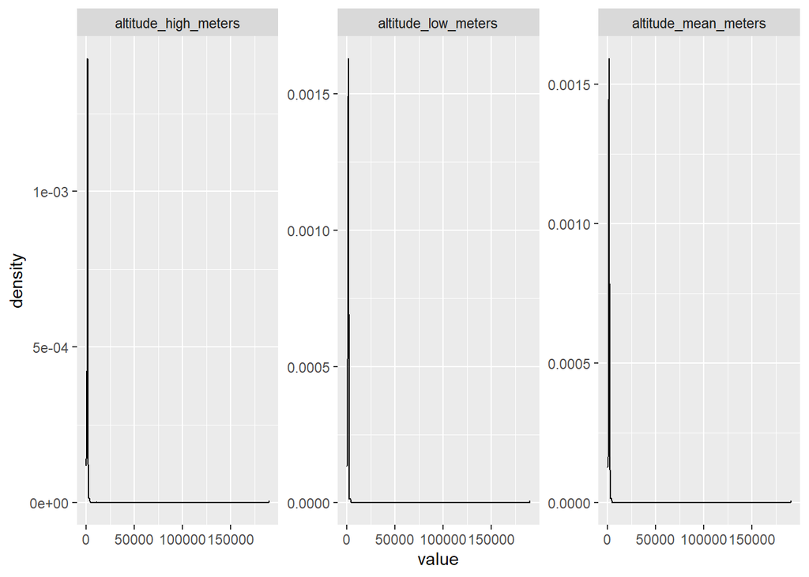

```r
altitudes <- c("altitude_low_meters",   "altitude_high_meters", "altitude_mean_meters")
coffee_ratings %>%
  select(all_of(altitudes)) %>%
  gather(na.rm = TRUE) %>%
  ggplot(aes(value)) +
  facet_wrap(~ key, scales = "free") +
  geom_density()
```

Check out the extreme values

```r
sort(coffee_ratings$altitude_mean_meters, decreasing = TRUE) %>% head(10)
```

```
##  [1] 190164 190164 110000  11000   4287   4001   3850   3845   3825   3800
```

After removing erroneous values

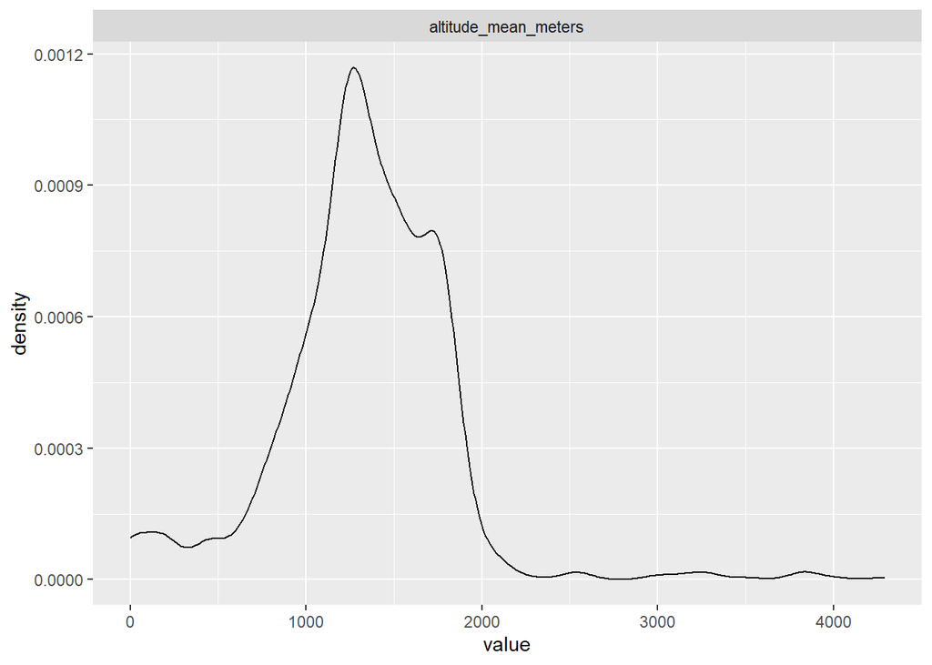

```r
coffee_ratings %>%
  select(altitude_mean_meters) %>%
  filter(altitude_mean_meters<4300) %>%
  gather(na.rm = TRUE) %>%
  ggplot(aes(value)) +
  facet_wrap(~ key, scales = "free") +
  geom_density()
```

Check distribution of grades

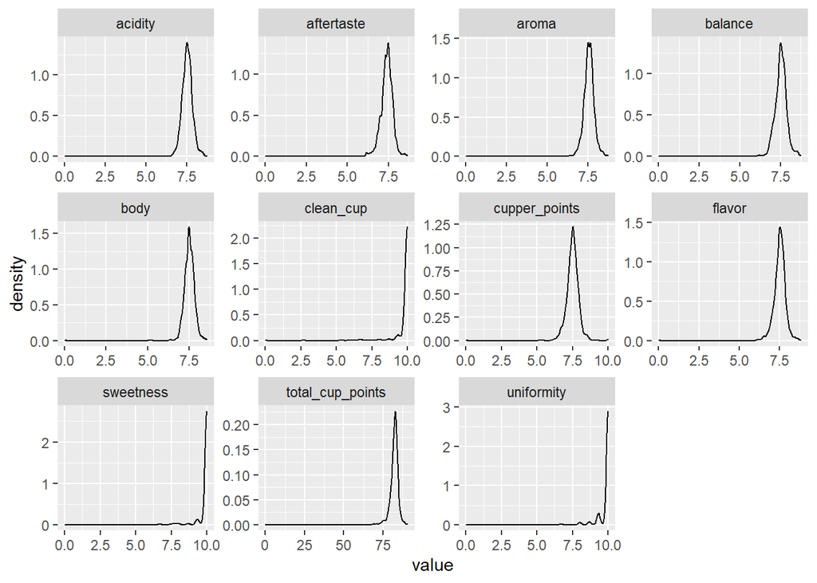

```r
grades <- c("aroma",    "flavor",   "aftertaste",   "acidity",  "body", "balance",  "uniformity",   "clean_cup",    "sweetness",    "cupper_points",    "total_cup_points")

coffee_ratings %>%
  select(all_of(grades)) %>%
  gather() %>%
  ggplot(aes(value)) +
  facet_wrap(~ key, scales = "free") +
  geom_density()
```

Check total score stats

```r
summary(coffee_ratings$total_cup_points)
```

```
##    Min. 1st Qu.  Median    Mean 3rd Qu.    Max.
##    0.00   81.08   82.50   82.09   83.67   90.58
```

Check out the extreme values

```r
sort(coffee_ratings$total_cup_points) %>% head(10)
```

```
##  [1]  0.00 59.83 63.08 67.92 68.33 69.17 69.17 69.33 70.67 70.75
```

Only one zero value

```r
coffee_ratings %>%
  filter(total_cup_points == 0) %>%
  select(grades)
```

```
## Note: Using an external vector in selections is ambiguous.
## ℹ Use `all_of(grades)` instead of `grades` to silence this message.
## ℹ See <https://tidyselect.r-lib.org/reference/faq-external-vector.html>.
```

```
## # A tibble: 1 × 11
##   aroma flavor aftertaste acidity  body balance uniformity clean_cup sweetness
##   <dbl>  <dbl>      <dbl>   <dbl> <dbl>   <dbl>      <dbl>     <dbl>     <dbl>
## 1     0      0          0       0     0       0          0         0         0
## # … with 2 more variables: cupper_points <dbl>, total_cup_points <dbl>
```

Received zero on all measures

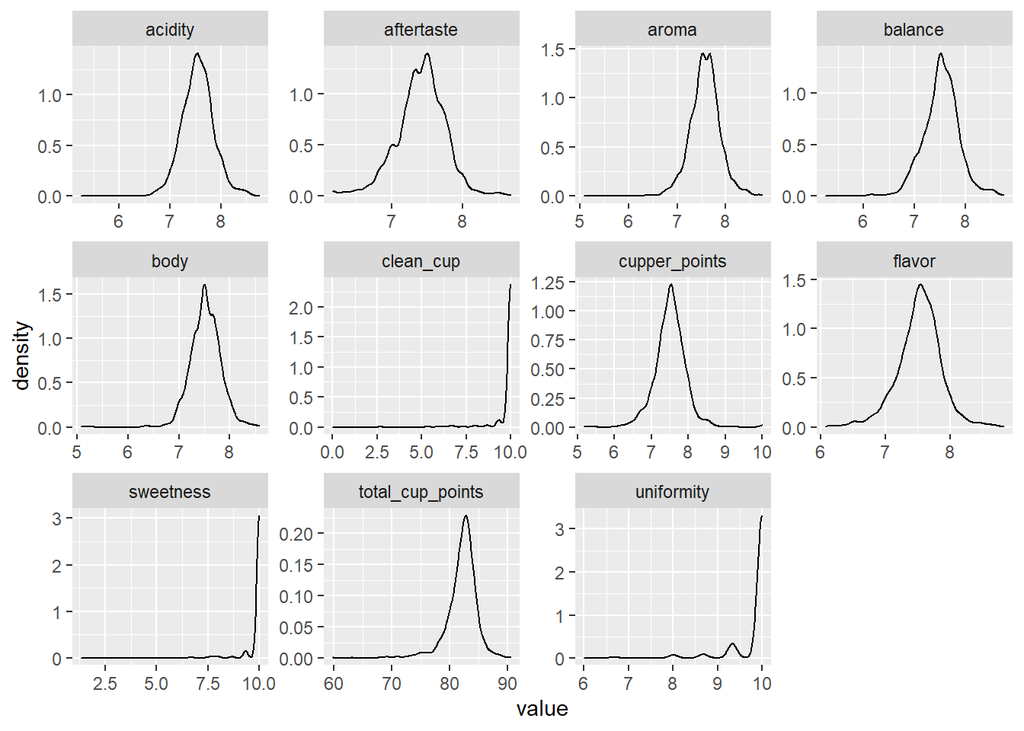

```r
coffee_ratings %>%
  filter(total_cup_points > 0) %>%
  select(grades) %>%
  gather() %>%
  ggplot(aes(value)) +
  facet_wrap(~ key, scales = "free") +
  geom_density()
```

It’s easy to score high on clean cup, uniformity, and sweetness? “Uniformity refers to consistency of flavor of the different cups of the sample tasted.” “Clean Cup refers to a lack of interfering negative impressions from first ingestion to final aftertaste” “Sweetness” no longer part of the CQI scale? “Acidity is often described as”brightness” when favorable or “sour” when unfavorable. At its best, acidity contributes to a coffee’s liveliness, sweetness, and fresh- fruit character and is almost immediately experienced and evaluated when the coffee is first slurped into the mouth”